# Linear regression in R

Cheatsheet

Published

September 6, 2024

**License**

This work was developed using resources that are available under a [Creative Commons Attribution 4.0 International License](https://creativecommons.org/licenses/by/4.0/), made available on the [SOLES Open Educational Resources](https://github.com/usyd-soles-edu) repository by the School of Life and Environmental Sciences, The University of Sydney.

**Assumed knowledge**

- You know how to install and load packages in R.
- You know how to import data into R.
- You recognise data frames and vectors.

**Data structure**

The data should be in a **long format** (also known as tidy data), where each row is an observation and each column is a variable (Figure 1). If your data is not already structured this way, reshape it manually in a spreadsheet program or in R using the `pivot_longer()` function from the `tidyr` package.

| Sex | BW |
| --- | --- |
| F | 2.15 |
| M | 2.55 |
| F | 2.95 |
| F | 2.70 |
| M | 2.20 |
| F | 1.85 |
| M | 2.55 |
| M | 2.60 |

| F | M |
| --- | --- |
| 2.15 | 2.55 |
| 2.95 | 2.20 |
| 2.70 | 2.55 |
| 1.85 | 2.60 |

Figure 1: Data should be in long format (left) where each row is an observation and each column is a variable. This is the preferred format for most statistical software. Wide format (right) is also common, but may require additional steps to analyse or visualise in some instances.

**Data**

For this cheatsheet we will use data from the penguins dataset from the `palmerpenguins` package. You may need to install this package:

```r
install.packages("palmerpenguins")
data(penguins)
```

## About

Regression analysis is the most commonly used statistical technique for modelling the relationship between variables that can be continuous, categorical or a mix of both. In fact, other techniques such as the *t*-test, ANOVA, ANCOVA and even non-parametric tests can be considered as special cases of regression analysis. In this cheatsheet, we will focus on **linear regression**.

## Implementing linear models

#### Simple linear regression

```r
fit01 <- lm(body_mass_g ~ flipper_length_mm, data = penguins)
```

#### Multiple linear regression

```r
fit02 <- lm(body_mass_g ~ flipper_length_mm + bill_length_mm,
    data = penguins
)
```

#### Interactions

```r
fit03 <- lm(body_mass_g ~ flipper_length_mm * bill_length_mm,
    data = penguins
)
```

#### Regression involving categorical variables

```r
fit04 <- lm(body_mass_g ~ species + sex, data = penguins)
```

#### Regression involving a mix of continuous and categorical variables

```r
fit04 <- lm(body_mass_g ~ species + flipper_length_mm,
    data = penguins
)
```

## Assumptions

Use the `plot()` function on the linear mode object to check the assumptions of the linear regression model.

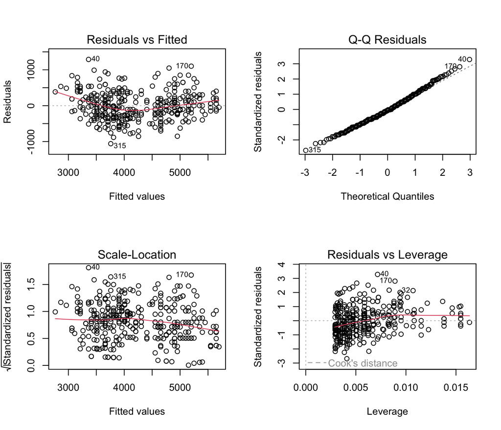

```r
par(mfrow = c(2, 2)) # Set up a 2x2 grid of plots
plot(fit01)
```

```r
par(mfrow = c(1, 1)) # Reset the plot layout
```

## Viewing interactions

Use the `emmeans()` function to interpret interactions in a linear model. For continuous variables, you need to specify the range of the covariate with the `cov.reduce` argument – set to `range` to avoid the default of using the mean.

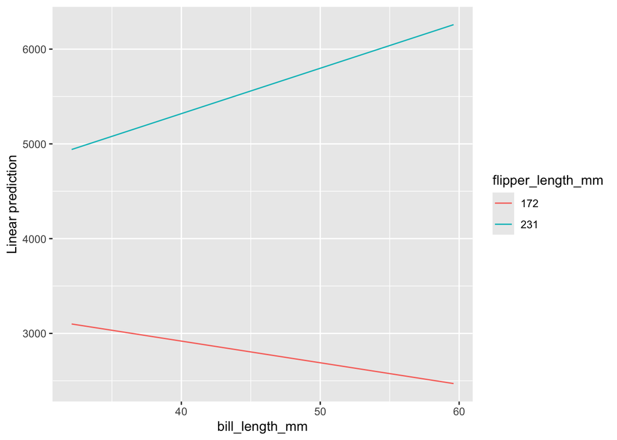

```r
emmip(fit03, flipper_length_mm ~ bill_length_mm, cov.reduce = range)
```

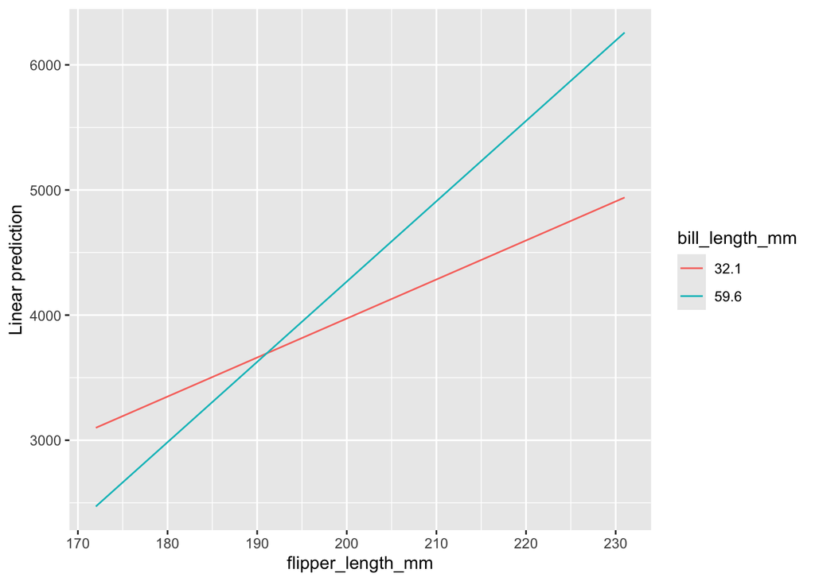

```r
emmip(fit03, bill_length_mm ~ flipper_length_mm, cov.reduce = range)
```

## Other resources

- It might be worthwhile to use the [`performance`](https://easystats.github.io/performance/) package to assess model fit (including assumptions using `check_model()`).
- I use this a lot: the [`interactions`](https://interactions.jacob-long.com/) package for visualising interactions in GLM models. However it is very technical and not for beginners – use if you are comfortable with R.
- The [`gtsummary`](https://www.danieldsjoberg.com/gtsummary/) package is great for summarising regression models using [`tbl_regression()`](https://www.danieldsjoberg.com/gtsummary/reference/tbl_regression.html), but you may need to tweak it further to get the output you want. Another package that can do something similar is the `sjPlot` package, using [`tab_model()`](https://strengejacke.github.io/sjPlot/reference/tab_model.html). **Alternatively, you can manually create the table (sometimes it can be easier to copy numbers depending on your level of expertise).**